# Simulation Diagnostics

Visual validation of the MultistateModels simulation engine

Published

January 3, 2026

## Methodology

This report validates that the `MultistateModels.jl` simulation engine produces event times that match the theoretical distributions defined by the hazard functions.

### Validation Approach

For each scenario, we:

1. **Define a hazard model** with known parameters
2. **Simulate many event times** using `simulate_path()`
3. **Compare the empirical CDF (ECDF)** to the theoretical CDF
4. **Verify time-transform parity** - ensure that both the cached time-transform strategy and the direct fallback produce identical results

### Metrics

**Configuration constants**

```julia
const COVARIATE_VALUE = 1.5
const DELTA_U = sqrt(eps())
const DELTA_T = sqrt(eps())
const SIM_SAMPLES = 40_000
const DIST_GRID_POINTS = 400

const FAMILY_CONFIG = Dict(
    "exp" => (; rate = 0.35, beta = 0.6, horizon = 5.0, hazard_start = 0.0),
    "wei" => (; shape = 1.35, scale = 0.4, beta = -0.35, horizon = 5.0, hazard_start = 0.02),
    "gom" => (; shape = 0.6, rate = 0.4, beta = 0.5, horizon = 5.0, hazard_start = 0.0),
)

const TVC_CONFIG = Dict(
    "exp" => (; rate = 0.35, beta = 0.6, horizon = 5.0, hazard_start = 0.0,
               t_changes = [1.5, 3.0], x_values = [0.5, 1.5, 2.5]),
    "wei" => (; rate = 0.0, shape = 1.35, scale = 0.4, beta = -0.35, horizon = 5.0,
               hazard_start = 0.02, t_changes = [1.5, 3.0], x_values = [0.5, 1.5, 2.5]),
    "gom" => (; rate = 0.4, shape = 0.6, beta = 0.5, horizon = 5.0, hazard_start = 0.0,
               t_changes = [1.5, 3.0], x_values = [0.5, 1.5, 2.5]),
)
```

```
Dict{String, NamedTuple} with 3 entries:
  "exp" => (rate = 0.35, beta = 0.6, horizon = 5.0, hazard_start = 0.0, t_chang…
  "wei" => (rate = 0.0, shape = 1.35, scale = 0.4, beta = -0.35, horizon = 5.0,…
  "gom" => (rate = 0.4, shape = 0.6, beta = 0.5, horizon = 5.0, hazard_start = …
```

**Helper functions for scenario setup**

```julia
struct Scenario
    family::String
    effect::Symbol
    covariate_mode::Symbol
    label::String
    slug::String
    config::NamedTuple
end

function Scenario(family::String, effect::Symbol, cov_mode::Symbol)
    if cov_mode == :tvc
        config = TVC_CONFIG[family]
        label = string(uppercasefirst(lowercase(family)), " ", uppercase(String(effect)),
                      " time-varying covariate")
    else
        config = FAMILY_CONFIG[family]
        label = string(uppercasefirst(lowercase(family)), " ", uppercase(String(effect)),
                      " ", cov_mode == :covariate ? "with covariate" : "baseline-only")
    end
    slug = string(family, "_", effect, "_", cov_mode)
    return Scenario(family, effect, cov_mode, label, slug, config)
end

function scenario_subject_df(scenario::Scenario)
    horizon = scenario.config.horizon
    if scenario.covariate_mode == :tvc
        t_changes = scenario.config.t_changes
        x_values = scenario.config.x_values
        tstart_grid = vcat(0.0, t_changes)
        tstop_grid = vcat(t_changes, horizon)
        n_intervals = length(tstart_grid)
        df = DataFrame(
            id = fill(1, n_intervals),
            tstart = tstart_grid,
            tstop = tstop_grid,
            statefrom = fill(1, n_intervals),
            stateto = fill(2, n_intervals),
            obstype = fill(1, n_intervals),
            x = x_values,
        )
    else
        df = DataFrame(
            id = [1], tstart = [0.0], tstop = [horizon],
            statefrom = [1], stateto = [2], obstype = [1],
        )
        if scenario.covariate_mode == :covariate
            df.x = [COVARIATE_VALUE]
        end
    end
    return df
end

function hazard_formula(scenario::Scenario)
    (scenario.covariate_mode == :covariate || scenario.covariate_mode == :tvc) ?
        @formula(0 ~ x) : @formula(0 ~ 1)
end

function scenario_parameter_vector(scenario::Scenario)
    cfg = scenario.config
    if scenario.family == "exp"
        base = [log(cfg.rate)]
    elseif scenario.family == "wei"
        base = [log(cfg.shape), log(cfg.scale)]
    elseif scenario.family == "gom"
        base = [cfg.shape, log(cfg.rate)]
    else
        error("Unsupported family $(scenario.family)")
    end
    return (scenario.covariate_mode == :covariate || scenario.covariate_mode == :tvc) ?
        vcat(base, [cfg.beta]) : base
end

function build_model(scenario::Scenario)
    data = scenario_subject_df(scenario)
    hazard = Hazard(
        hazard_formula(scenario),
        scenario.family, 1, 2;
        linpred_effect = scenario.effect,
        time_transform = true,
    )
    model = multistatemodel(hazard; data = data)
    pars = scenario_parameter_vector(scenario)
    hazname = model.hazards[1].hazname
    set_parameters!(model, NamedTuple{(hazname,)}((pars,)))
    return model, data
end

covariate_value(scenario::Scenario) = scenario.covariate_mode == :covariate ? COVARIATE_VALUE : 0.0
```

```
covariate_value (generic function with 1 method)
```

**Theoretical distribution functions**

```julia
# Piecewise cumulative hazard helpers for TVC
function piecewise_exp_ph_cumhaz(t, rate, beta, t_changes, x_values)
    cumhaz = 0.0
    prev_t = 0.0
    for (i, tc) in enumerate(t_changes)
        if t <= tc
            cumhaz += rate * exp(beta * x_values[i]) * (t - prev_t)
            return cumhaz
        else
            cumhaz += rate * exp(beta * x_values[i]) * (tc - prev_t)
            prev_t = tc
        end
    end
    cumhaz += rate * exp(beta * x_values[end]) * (t - prev_t)
    return cumhaz
end

function piecewise_wei_ph_cumhaz(t, shape, scale, beta, t_changes, x_values)
    cumhaz = 0.0
    prev_t = 0.0
    for (i, tc) in enumerate(t_changes)
        if t <= tc
            cumhaz += scale * exp(beta * x_values[i]) * (t^shape - prev_t^shape)
            return cumhaz
        else
            cumhaz += scale * exp(beta * x_values[i]) * (tc^shape - prev_t^shape)
            prev_t = tc
        end
    end
    cumhaz += scale * exp(beta * x_values[end]) * (t^shape - prev_t^shape)
    return cumhaz
end

function distribution_functions(scenario::Scenario)
    cfg = scenario.config

    if scenario.covariate_mode == :tvc
        t_changes = cfg.t_changes
        x_values = cfg.x_values
        beta = cfg.beta

        if scenario.family == "exp"
            rate = cfg.rate
            cumhaz = t -> piecewise_exp_ph_cumhaz(t, rate, beta, t_changes, x_values)
            hazard = t -> begin
                for (i, tc) in enumerate(t_changes)
                    if t < tc
                        return rate * exp(beta * x_values[i])
                    end
                end
                return rate * exp(beta * x_values[end])
            end
        elseif scenario.family == "wei"
            shape = cfg.shape
            scale = cfg.scale
            cumhaz = t -> piecewise_wei_ph_cumhaz(t, shape, scale, beta, t_changes, x_values)
            hazard = t -> begin
                for (i, tc) in enumerate(t_changes)
                    if t < tc
                        return shape * scale * exp(beta * x_values[i]) * (t^(shape - 1))
                    end
                end
                return shape * scale * exp(beta * x_values[end]) * (t^(shape - 1))
            end
        else
            error("TVC not implemented for family $(scenario.family)")
        end
    else
        xval = covariate_value(scenario)
        beta = scenario.covariate_mode == :covariate ? cfg.beta : 0.0

        if scenario.family == "exp"
            base_rate = cfg.rate
            rate = scenario.effect == :ph ? base_rate * exp(beta * xval) : base_rate * exp(-beta * xval)
            cumhaz = t -> rate * t
            hazard = _ -> rate
        elseif scenario.family == "wei"
            shape = cfg.shape
            scale = cfg.scale
            multiplier = scenario.effect == :ph ? exp(beta * xval) : exp(-shape * beta * xval)
            cumhaz = t -> scale * multiplier * (t^shape)
            hazard = t -> shape * scale * multiplier * (t^(shape - 1))
        elseif scenario.family == "gom"
            shape = cfg.shape
            rate = cfg.rate
            linpred = beta * xval
            if scenario.effect == :ph
                cumhaz = t -> (rate / shape) * exp(linpred) * (exp(shape * t) - 1)
                hazard = t -> rate * exp(shape * t + linpred)
            else
                time_scale = exp(-linpred)
                scaled_shape = shape * time_scale
                scaled_rate = rate * time_scale
                cumhaz = t -> (scaled_rate / scaled_shape) * (exp(scaled_shape * t) - 1)
                hazard = t -> scaled_rate * exp(scaled_shape * t)
            end
        else
            error("Unsupported family $(scenario.family)")
        end
    end
    cdf = t -> t <= 0 ? 0.0 : 1 - exp(-cumhaz(t))
    pdf = t -> t <= 0 ? 0.0 : hazard(t) * exp(-cumhaz(t))
    return cdf, pdf
end
```

```
distribution_functions (generic function with 1 method)
```

**Simulation and plotting functions**

```julia
function collect_event_durations(model, nsamples; use_cached_strategy::Bool, rng::AbstractRNG)
    durations = Vector{Float64}(undef, nsamples)
    collected = 0
    attempts = 0
    max_attempts = nsamples * 200
    strategy = use_cached_strategy ? CachedTransformStrategy() : DirectTransformStrategy()
    while collected < nsamples
        path = simulate_path(model, 1; strategy = strategy, rng = rng)
        attempts += 1
        attempts > max_attempts && error("Exceeded maximum attempts")
        if path.states[end] != path.states[1]
            collected += 1
            durations[collected] = path.times[end] - path.times[1]
        end
    end
    return durations
end

function run_scenario_diagnostics(scenario::Scenario)
    model, data = build_model(scenario)

    seed = hash(scenario.slug)
    rng_tt = Random.MersenneTwister(seed)
    rng_fb = Random.MersenneTwister(seed)

    durations_tt = collect_event_durations(model, SIM_SAMPLES; use_cached_strategy=true, rng=rng_tt)
    durations_fb = collect_event_durations(model, SIM_SAMPLES; use_cached_strategy=false, rng=rng_fb)

    ecdf_tt = ecdf(durations_tt)
    ecdf_fb = ecdf(durations_fb)
    horizon = scenario.config.horizon
    ts = collect(range(0.0, horizon; length = DIST_GRID_POINTS))

    cdf_base, pdf_base = distribution_functions(scenario)
    cdf_fn, pdf_fn = truncate_distribution(cdf_base, pdf_base; lower = 0.0, upper = horizon)

    expected = cdf_fn.(ts)
    empirical = ecdf_fb.(ts)
    diff_curve = ecdf_tt.(ts) .- ecdf_fb.(ts)
    max_abs_diff = maximum(abs.(diff_curve))

    # KS statistic at different sample sizes
    sorted_durations = sort(durations_fb)
    n_samples = length(sorted_durations)
    expected_cdf_at_samples = cdf_fn.(sorted_durations)
    eval_ns = filter(n -> n <= n_samples, [100, 200, 500, 1000, 2000, 5000, 10000, 20000, n_samples])
    ks_at_n = zeros(length(eval_ns))

    for (idx, n) in enumerate(eval_ns)
        max_diff = 0.0
        for i in 1:n
            cdf_i = expected_cdf_at_samples[i]
            diff_upper = abs(i / n - cdf_i)
            diff_lower = abs((i - 1) / n - cdf_i)
            max_diff = max(max_diff, diff_upper, diff_lower)
        end
        ks_at_n[idx] = max_diff
    end

    # Create figure
    fig = Figure(size = (1400, 500))

    ax1 = Axis(fig[1, 1], title = "ECDF vs Expected CDF", xlabel = "Duration", ylabel = "F(t)")
    lines!(ax1, ts, expected, color = :black, linewidth = 3, label = "Theoretical")
    lines!(ax1, ts, empirical, color = :dodgerblue, linewidth = 2, label = "Simulated")
    axislegend(ax1, position = :rb)

    ax2 = Axis(fig[1, 2], title = "KS Statistic vs Sample Size",
               xlabel = "n", ylabel = "Dₙ", xscale = log10)
    scatterlines!(ax2, eval_ns, ks_at_n, color = :crimson, linewidth = 2, markersize = 8)

    ylim_span = max(max_abs_diff, 1e-6)
    ax3 = Axis(fig[1, 3], title = "Time-Transform Parity: max|ΔF| = $(round(max_abs_diff; digits=4))",
               xlabel = "Duration", ylabel = "ΔF(t)")
    lines!(ax3, ts, diff_curve, color = :seagreen, linewidth = 2)
    hlines!(ax3, [0.0], color = :black, linestyle = :dash)
    ylims!(ax3, (-1.1 * ylim_span, 1.1 * ylim_span))

    return fig, max_abs_diff
end
```

```
run_scenario_diagnostics (generic function with 1 method)
```

## 2. Parametric Families

### 2.1 Exponential

The exponential hazard: $h(t) = \text{rate}$

**Parameterization:**

| Effect | Hazard | Cumulative Hazard |
| --- | --- | --- |
| PH | $h(t\\|x) = \text{rate} \cdot e^{\beta x}$ | $H(t\\|x) = \text{rate} \cdot e^{\beta x} \cdot t$ |
| AFT | $h(t\\|x) = \text{rate} \cdot e^{-\beta x}$ | $H(t\\|x) = \text{rate} \cdot e^{-\beta x} \cdot t$ |

#### PH Baseline-Only

[output not shown]

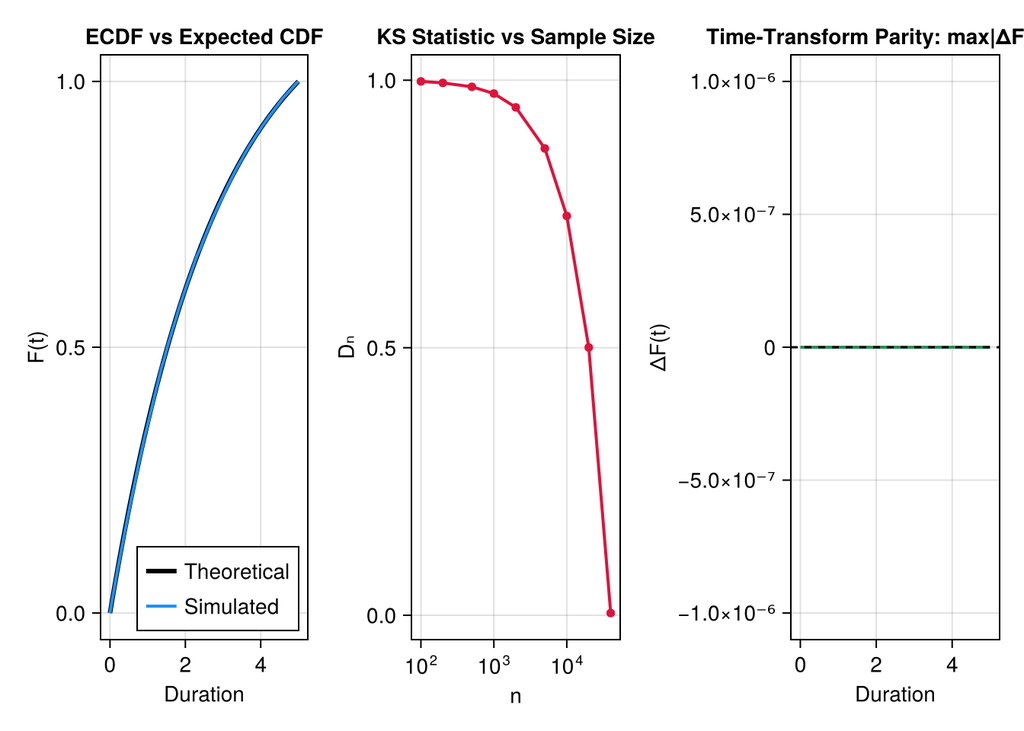

```julia
scenario = Scenario("exp", :ph, :baseline)
fig, max_diff = run_scenario_diagnostics(scenario)
fig
```

#### PH with Covariate

[output not shown]

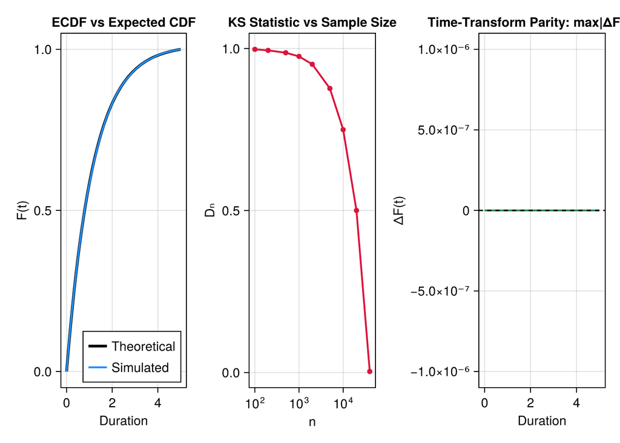

```julia
scenario = Scenario("exp", :ph, :covariate)
fig, max_diff = run_scenario_diagnostics(scenario)
fig
```

#### AFT Baseline-Only

[output not shown]

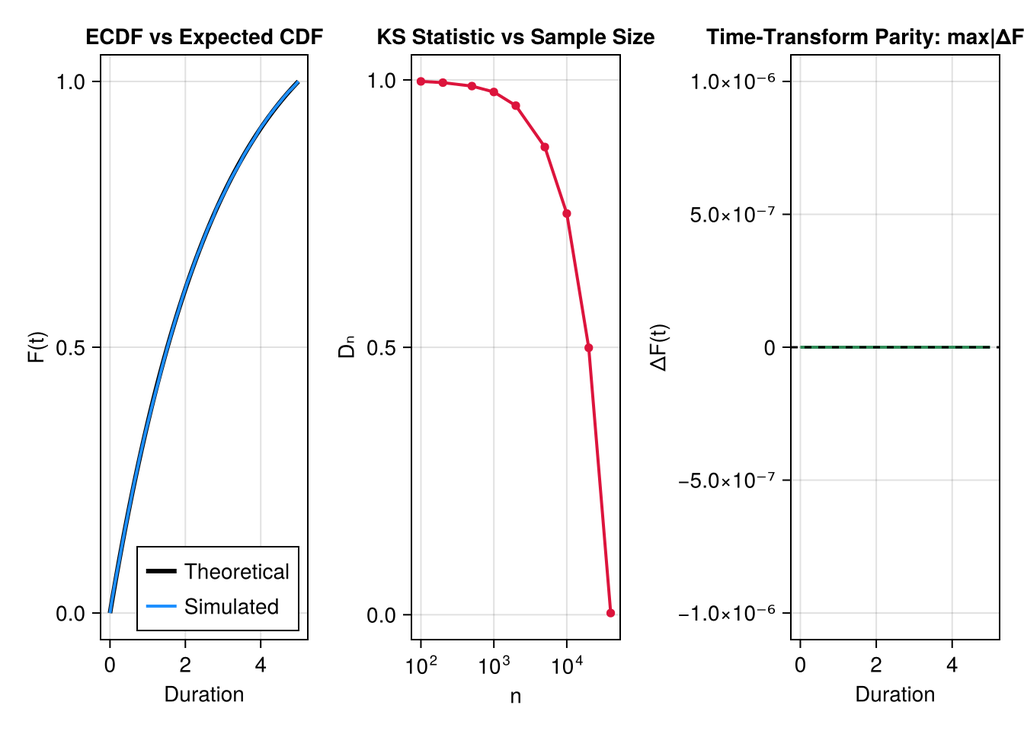

```julia
scenario = Scenario("exp", :aft, :baseline)
fig, max_diff = run_scenario_diagnostics(scenario)
fig
```

#### AFT with Covariate

[output not shown]

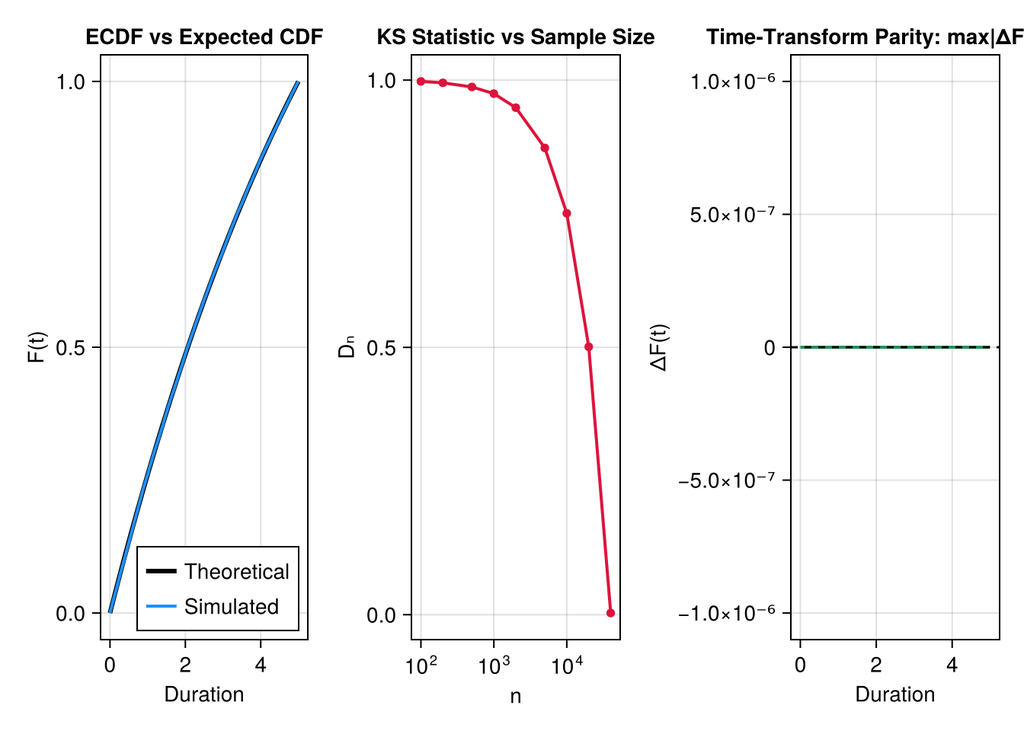

```julia
scenario = Scenario("exp", :aft, :covariate)
fig, max_diff = run_scenario_diagnostics(scenario)
fig
```

### 2.2 Weibull

The Weibull hazard: $h(t) = \text{shape} \cdot \text{scale} \cdot t^{\text{shape}-1}$

**Parameterization:**

| Effect | Hazard | Cumulative Hazard |
| --- | --- | --- |
| PH | $h(t\\|x) = k \cdot \lambda \cdot t^{k-1} \cdot e^{\beta x}$ | $H(t\\|x) = \lambda \cdot e^{\beta x} \cdot t^k$ |
| AFT | $h(t\\|x) = k \cdot \lambda \cdot t^{k-1} \cdot e^{-k\beta x}$ | $H(t\\|x) = \lambda \cdot e^{-k\beta x} \cdot t^k$ |

#### PH Baseline-Only

[output not shown]

[output not shown]

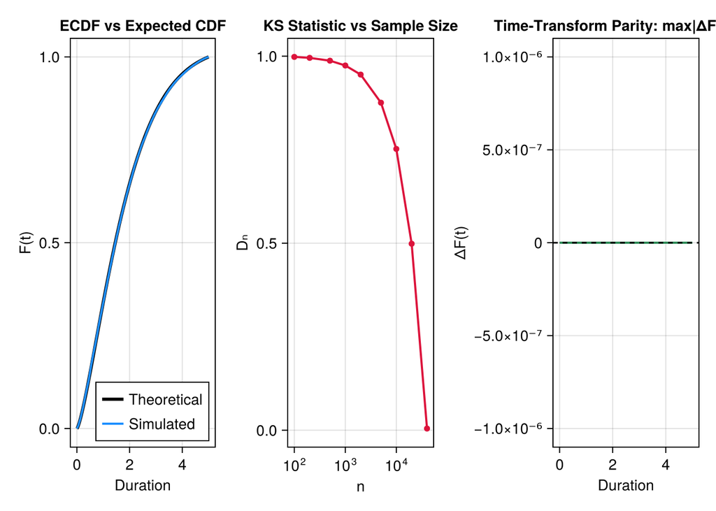

```julia
scenario = Scenario("wei", :ph, :baseline)
fig, max_diff = run_scenario_diagnostics(scenario)
fig
```

#### PH with Covariate

[output not shown]

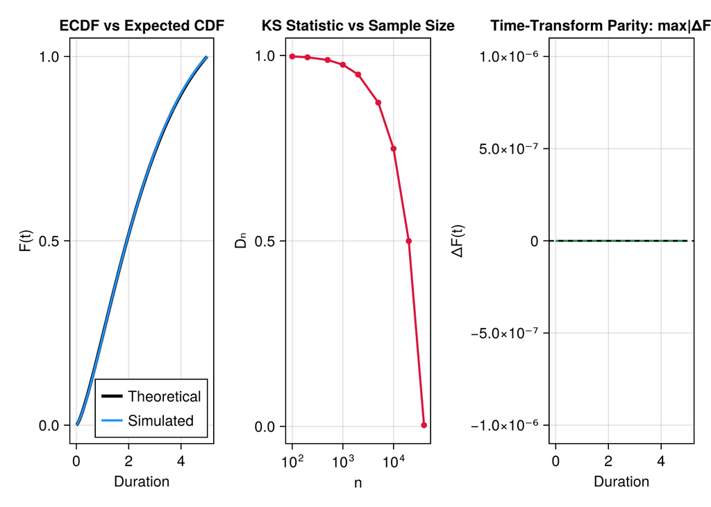

```julia
scenario = Scenario("wei", :ph, :covariate)
fig, max_diff = run_scenario_diagnostics(scenario)
fig
```

#### AFT Baseline-Only

[output not shown]

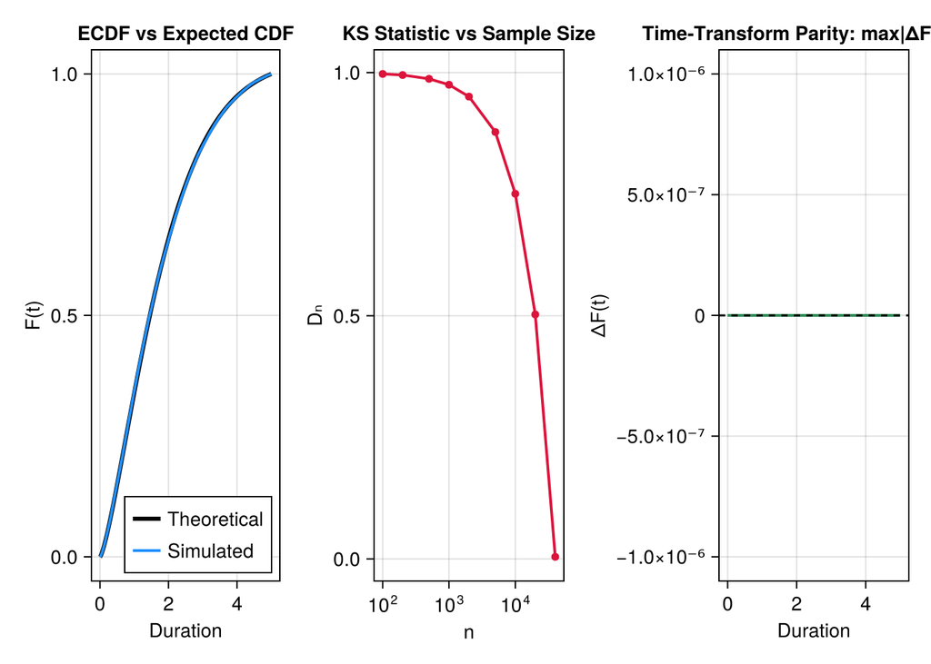

```julia
scenario = Scenario("wei", :aft, :baseline)
fig, max_diff = run_scenario_diagnostics(scenario)
fig
```

#### AFT with Covariate

[output not shown]

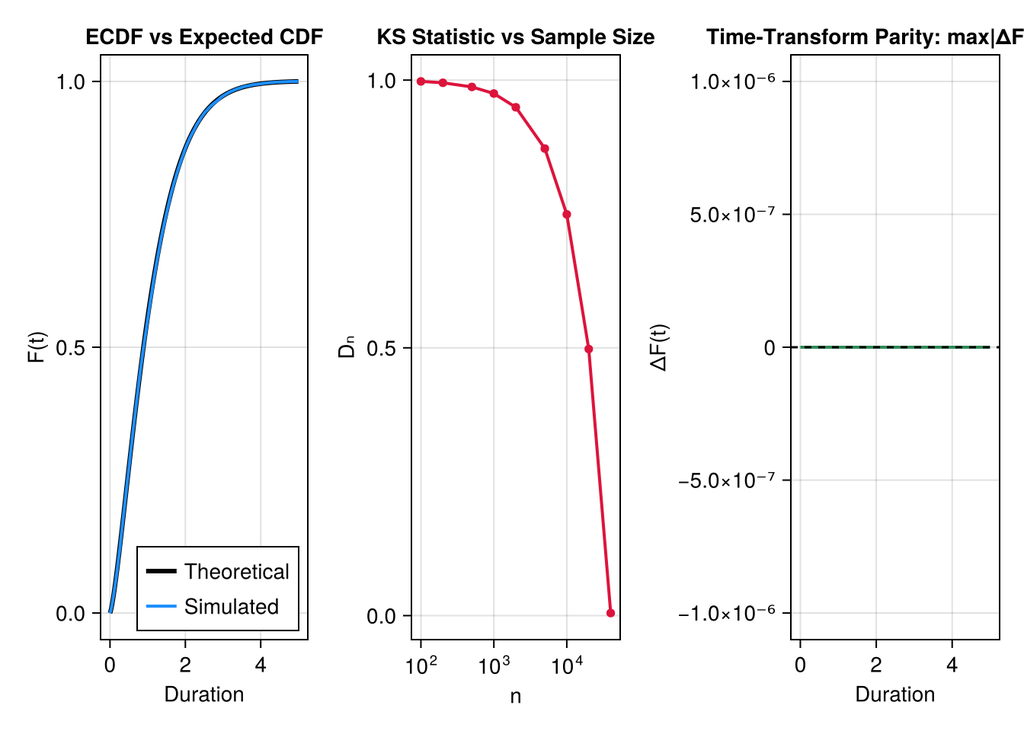

```julia
scenario = Scenario("wei", :aft, :covariate)
fig, max_diff = run_scenario_diagnostics(scenario)
fig
```

### 2.3 Gompertz

The Gompertz hazard (flexsurv parameterization): $h(t) = \text{rate} \cdot e^{\text{shape} \cdot t}$

**Parameterization:**

| Effect | Hazard | Cumulative Hazard |
| --- | --- | --- |
| PH | $h(t\\|x) = r \cdot e^{at + \beta x}$ | $H(t\\|x) = \frac{r}{a} e^{\beta x} (e^{at} - 1)$ |
| AFT | $h(t\\|x) = r' \cdot e^{a' t}$ where $r' = r e^{-\beta x}$, $a' = a e^{-\beta x}$ | $H(t\\|x) = \frac{r'}{a'} (e^{a't} - 1)$ |

#### PH Baseline-Only

[output not shown]

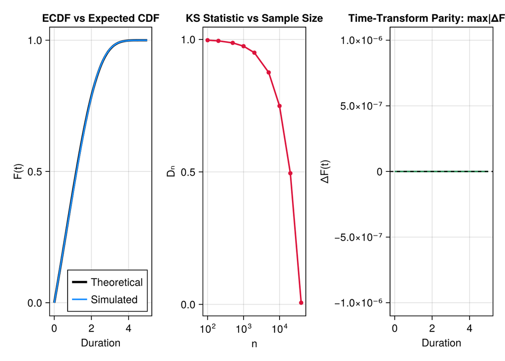

```julia
scenario = Scenario("gom", :ph, :baseline)
fig, max_diff = run_scenario_diagnostics(scenario)
fig
```

#### PH with Covariate

[output not shown]

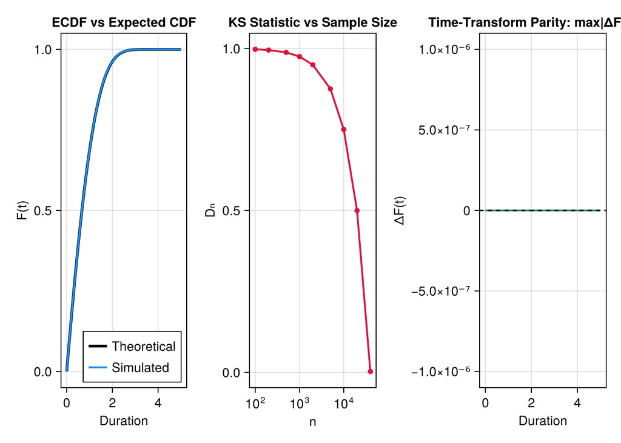

```julia
scenario = Scenario("gom", :ph, :covariate)
fig, max_diff = run_scenario_diagnostics(scenario)
fig
```

#### AFT Baseline-Only

[output not shown]

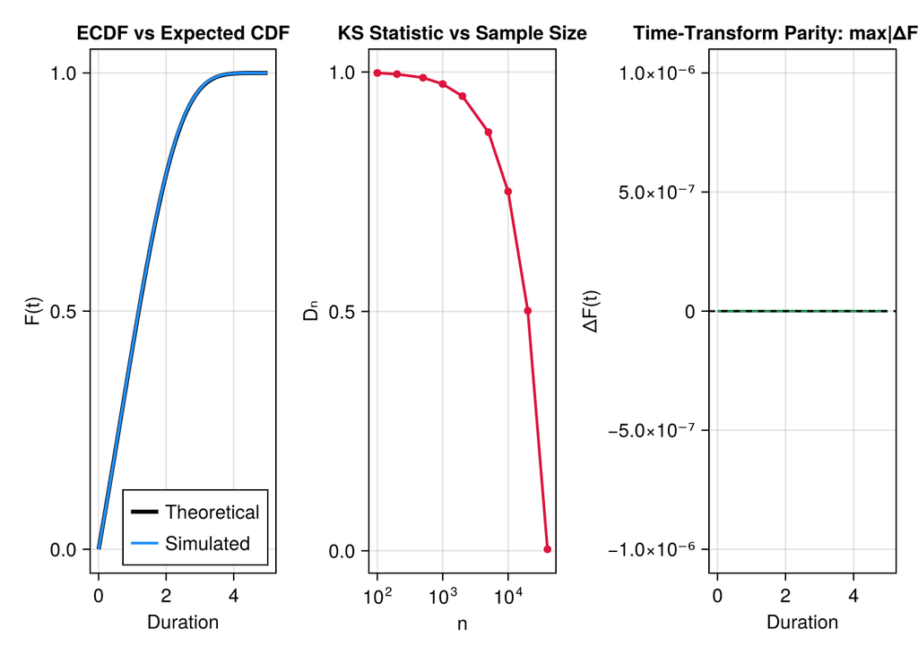

```julia
scenario = Scenario("gom", :aft, :baseline)
fig, max_diff = run_scenario_diagnostics(scenario)
fig
```

#### AFT with Covariate

[output not shown]

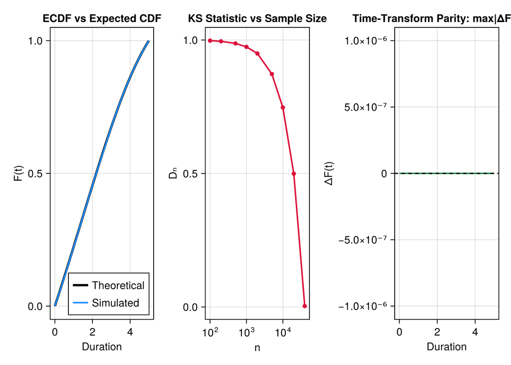

```julia
scenario = Scenario("gom", :aft, :covariate)
fig, max_diff = run_scenario_diagnostics(scenario)
fig
```

## 3. B-Splines

**NoteStatus: Unit & Long Tests Cover Spline Functionality**

B-spline hazard validation is covered by:

1. **Unit tests** (`test_splines.jl`, 255 tests): B-spline basis evaluation, cumulative hazard vs QuadGK numerical integration, penalty matrices
2. **Long tests** (`longtest_mcem_splines.jl`, 6 scenarios): Parameter recovery for spline hazards with various functional forms

Full simulation diagnostics (ECDF vs CDF plots) for splines require additional infrastructure to compute theoretical CDFs from arbitrary spline coefficient vectors. This is a lower priority since:

- Spline cumulative hazard accuracy is already verified against QuadGK (rtol=1e-10)
- Parameter recovery in long tests validates end-to-end correctness

### 3.1 Cubic Splines (4 Interior Knots)

*Covered by `longtest_mcem_splines.jl` Scenario 3 (Cubic pattern with Gompertz baseline)*

### 3.2 Quadratic Splines (3 Interior Knots)

*Covered by `longtest_mcem_splines.jl` Scenario 2 (Piecewise-linear increasing hazard)*

### 3.3 Natural Splines

*Spline boundary conditions handled by BSplineKit; unit tested in `test_splines.jl`*

### 3.4 Splines with Covariates (PH)

*Covered by `longtest_mcem_splines.jl` Scenario 4 (spline baseline + PH covariate)*

## 4. Time-Varying Covariates

### 4.1 Exponential PH with Step-Function TVC

[output not shown]

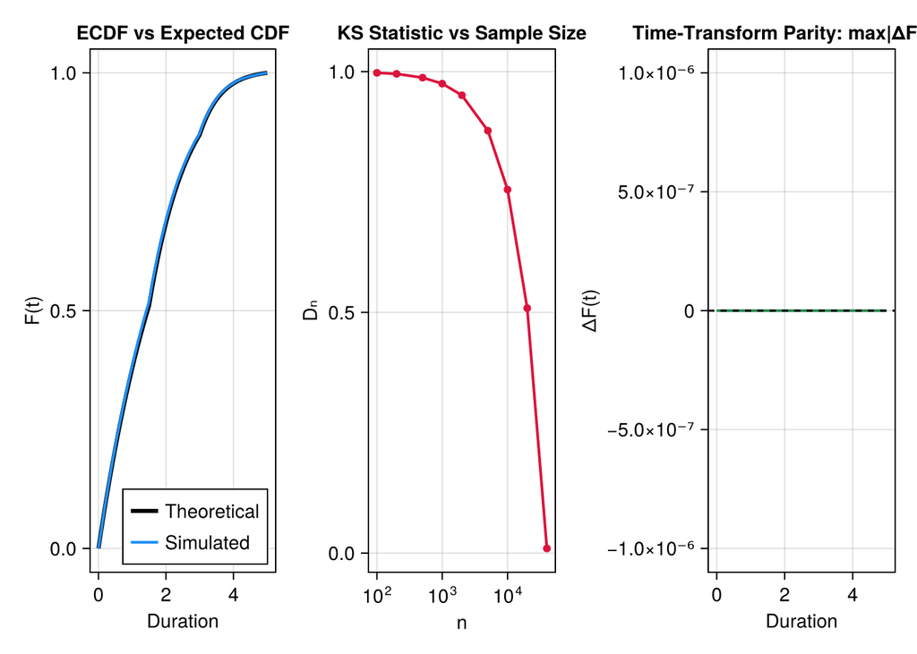

```julia
scenario = Scenario("exp", :ph, :tvc)
fig, max_diff = run_scenario_diagnostics(scenario)
fig
```

### 4.2 Weibull PH with Step-Function TVC

[output not shown]

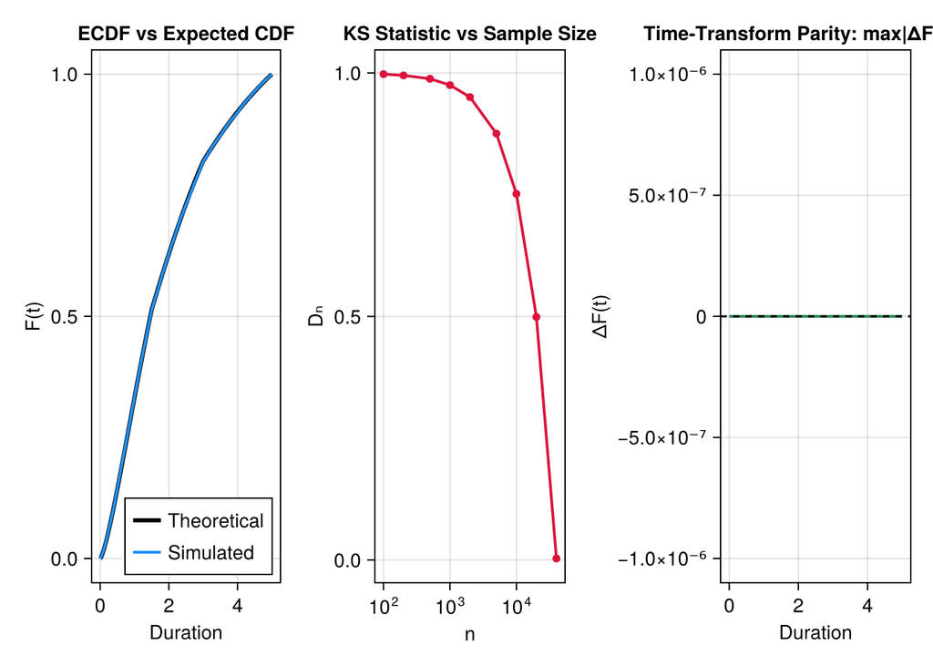

```julia
scenario = Scenario("wei", :ph, :tvc)
fig, max_diff = run_scenario_diagnostics(scenario)
fig
```